# Type of effects and regression models with R

L. Porcu / C. Chilamakuri

Last modified: 17 Feb 2025

# Section 1: Practicals

## (i) *Fish, tanks and food*

An experimenter investigating the effect of different food for a species of fish places the food in tanks containing the fish. The weight increase of the fish is the response (y<sub>ijy</sub>), where i,j and k are indices identifying the fish, the tank and the type of food, respectively.

- Please, identify fixed and random effects.
- Please, identify predictable and unpredictable (i.e. error) random effects.
- Please, write the equation of a reasonable regression model generating the response.

*Note:* this example has been taken from the following reference: Casella, George (2008). Statistical design. Berlin: Springer. ISBN 978-0-387-75965-4.

## (iii) *Systematic component of regression models*

The relationship between response FEV (lung capacity) and predictors age (x<sub>1</sub>), height (x<sub>2</sub>), gender (x<sub>3</sub>), smoking status (x<sub>4</sub>) and place of residence (x<sub>5</sub>) could be described by the following systematic components:

| $\mu$ | = | $\beta$<sub>0</sub> | + | $\beta$<sub>1</sub>x<sub>1</sub> | + | $\beta$<sub>2</sub>x<sub>2</sub> | + | $\beta$<sub>3</sub>x<sub>3</sub> | + | $\beta$<sub>4</sub>x<sub>4</sub> | + | $\beta$<sub>5</sub>x<sub>5</sub> |
| --- | --- | --- | --- | --- | --- | --- | --- | --- | --- | --- | --- | --- |
| 1/$\mu$ | = | 0 | + | e<sup>$\beta$<sub>1</sub>x<sub>1</sub></sup> | + | $\beta$<sub>2</sub>x<sub>2</sub><sup>(1/3)</sup> | + | 0 | + | $\beta$<sub>4</sub>x<sub>4</sub> | + | 0 |
| log<sub>e</sub>$\mu$ | = | $\beta$<sub>0</sub> | + | 0 | + | $\beta$<sub>2</sub>x<sub>2</sub> | + | $\beta$<sub>3</sub>x<sub>3</sub><sup>2</sup> | + | $\beta$<sub>4</sub>x<sub>4</sub> | + | $\beta$<sub>5</sub>x<sup>5</sup> |
| $\mu$ | = | $\beta$<sub>0</sub> | + | $\beta$x<sub>1</sub><sup>(1/2)</sup> | + | 0 | + | 0 | + | 0 | + | $\beta$<sub>5</sub>x<sub>5</sub> |

- Please, for each systematic component:
  1. identify the number of predictors
  2. identify the number of regression parameters
  3. is the mean FEV of the UK population analysed on natural scale?
  4. is the systematic component linear in the parameters?
  5. could the systematic component be used in a linear regression model?
- Can you give a meaning for the parameter $\beta$<sub>0</sub>?

# (iiii) *Noisy miners and number of eucalypt trees*

The data for this exercise are available in R as the data frame *nminer*, part of the **GLMsData** package<sup>1</sup>.  
Lets starts by

- installing the **GLMsData** package in R
- loading the **GLMsData** package and the *nminer* data frame
- displaying the first lines of data as follows:

```r
# install.packages("GLMData")  # Install the GLMsData package
library(GLMsData)              # Load the GLMsData package
data(nminer)                   # Make the data set nminer available for use
head(nminer)                   # Display the first few lines of data
```

```
##   Miners Eucs Area Grazed Shrubs Bulokes Timber Minerab
## 1      0    2   22      0      1     120     16       0
## 2      0   10   11      0      1      67     25       0
## 3      1   16   51      0      1      85     13       3
## 4      1   20   22      0      1      45     12       2
## 5      1   19    4      0      1     160     14       8
## 6      1   18   61      0      1      75      6       1
```

The noisy miner is a small but aggressive native Australian bird. A study<sup>2</sup> of the habitats of the noisy miner recorded the *number of noisy miners* (that is, the number observed; column `Minerab`) in two hectare transects located in buloke woodland patches with varying *numbers of eucalypt trees* ( column `Eucs`).

- Please, plot the *number of noisy miners* against the number of *numbers of eucalypt trees* by means of a scatter plot.

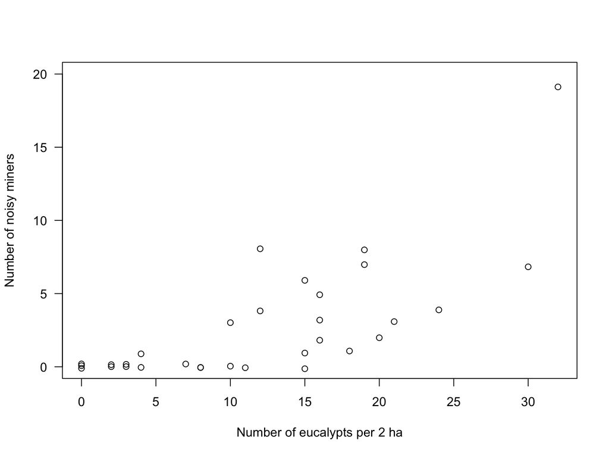

```r
plot( jitter(Minerab) ~ Eucs, data=nminer, las=1, ylim=c(0, 20),
      xlab="Number of eucalypts per 2 ha", ylab="Number of noisy miners" )
```

- Consider *number of noisy miners* as response and *numbers of eucalypt trees* as predictor.
  1. Is the relationship between the mean *number of noisy miners* ($\mu$) and the *numbers of eucalypt trees* linear?
  2. Does the random component have a constant variance?
  3. Could the normal distribution reasonably describe the random component?
  4. Is it possible to describe the distribution of the *number of noisy miners* as function of *numbers of eucalypt trees* using a linear regression model?
  5. Please, propose a reasonable regression model generating these data

*Note:* this example has been taken from the following reference: Dunn, Peter K. and Gordon K. Smyth. “Generalized Linear Models With Examples in R.” (2018).  
*References*:  
<sup>1</sup> Dunn, P.K., Smyth, G.K.: GLMsData: Generalized linear model data sets (2017). URL https://CRAN.R-project.org/package=GLMsData.  
<sup>2</sup> Maron, M.: Threshold effect of eucalypt density on an aggressive avian competitor. Biological Conservation 136, 100–107 (2007)